# What can we learn from a recorded situation?

Session 4 · Situated and multimodal observation

Generative AI in Sociology

2026-09-23

## One incident, several possible records

[figure not shown]

In the 2006 World Cup final, Zinedine Zidane head-butted Marco Materazzi.

Millions watched the same broadcast. They did not necessarily see the same event.

## What exactly did the cameras record?

**What is visible?**Bodies, spacing, gestures, movement and the response of other players.

**What is audible?**Stadium sound—but not a usable recording of the exchange between the players.

**What must be inferred?**The words spoken, how they were understood, and why Zidane turned back.

This is the problem for today: how does a recorded situation become sociological evidence?

## A second camera changes what we can inspect

[figure not shown]

**Tactical camera**  
The incident can be placed within the wider organization of the pitch.

Official FIFA footage, close broadcast and tactical-camera versions.

## The recording is already a selection

### The camera includes

one angle, a bounded field of view, a particular time span, and the sound available to the broadcaster.

### The camera excludes

other positions, unrecorded speech, bodily sensation, prior history, and much of what participants remember.

Before we ask an LLM to describe a scene, we need to understand the record we are giving it.

## Sociologists were studying these problems long before digital video

**Simmel**What do the senses allow people to know about one another?

**Mead**How does a gesture acquire meaning through another person’s response?

**Goffman**How is a face-to-face situation organized?

**Goodwin**How do professional practices teach us what to see?

## Simmel makes sensory access part of the social relation

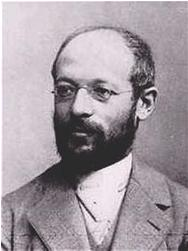

Georg Simmel

**Sight** allows mutual recognition at a distance.

**Hearing** brings people into a shared acoustic space.

**Proximity** changes what bodies can perceive and how quickly they can respond.

Simmel, Georg. 1997 [1907]. “Sociology of the Senses.” In *Simmel on Culture*, edited by D. Frisby and M. Featherstone.

## The football footage gives us sight without the crucial speech

**Visible:** Materazzi and Zidane move apart; Zidane turns.

**Not recorded:** a clear audio track of their words.

**Consequence:** later accounts of the insult cannot be read directly from the footage.

## Mead asks us to follow gesture and response together

1**Gesture**An action is directed toward another person.

2**Response**The other person acts in relation to it.

3**Meaning**The social act is understood through this unfolding relation.

For this case, a still of the head-butt is insufficient. We need the preceding movements and the responses that follow.

Mead, George Herbert. 1934. *Mind, Self, and Society*. Chicago: University of Chicago Press.

## Goffman directs attention to the situation around the act

[figure not shown]

playersofficialsaudiencerules of the match

The interaction takes place before teammates, officials, cameras and a stadium audience. Those people and rules are part of the situation.

Goffman, Erving. 1983. “The Interaction Order.” *American Sociological Review* 48(1):1–17.

## Sequence analysis asks what happened next—and what made that response relevant

**01**Materazzi moves behind Zidane and places an arm across his chest.

**02**He releases him; Zidane looks toward Materazzi.

**03**They move downfield while appearing to speak.

**04**Zidane moves ahead, turns and steps back toward Materazzi.

**05**Zidane lowers his head and makes contact with Materazzi’s chest.

Sequence summarized from OpenLearn, “Starting with psychology,” §6.3, using the broadcast footage as the observable record.

## Goodwin shows how an observer learns what to notice

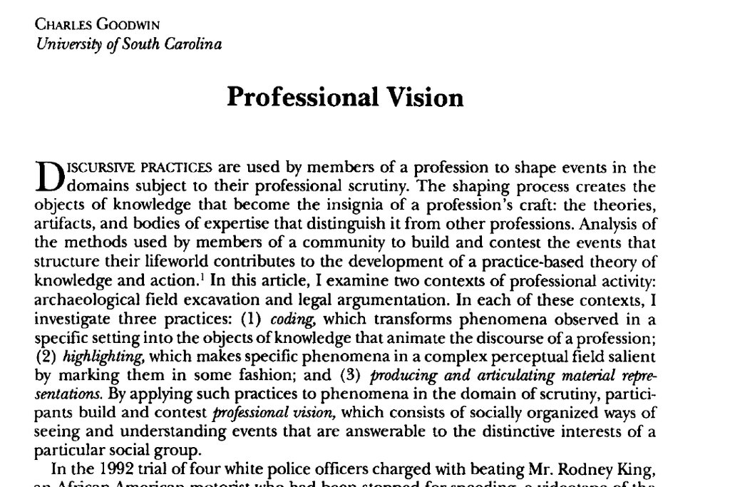

Goodwin studies archaeologists and courtroom lawyers.

In both settings, people use established practices to turn a complex visual field into professionally relevant evidence.

**His term is professional vision.**

Goodwin, Charles. 1994. “Professional Vision.” *American Anthropologist* 96(3):606–633.

## An archaeological colour chart organizes perception

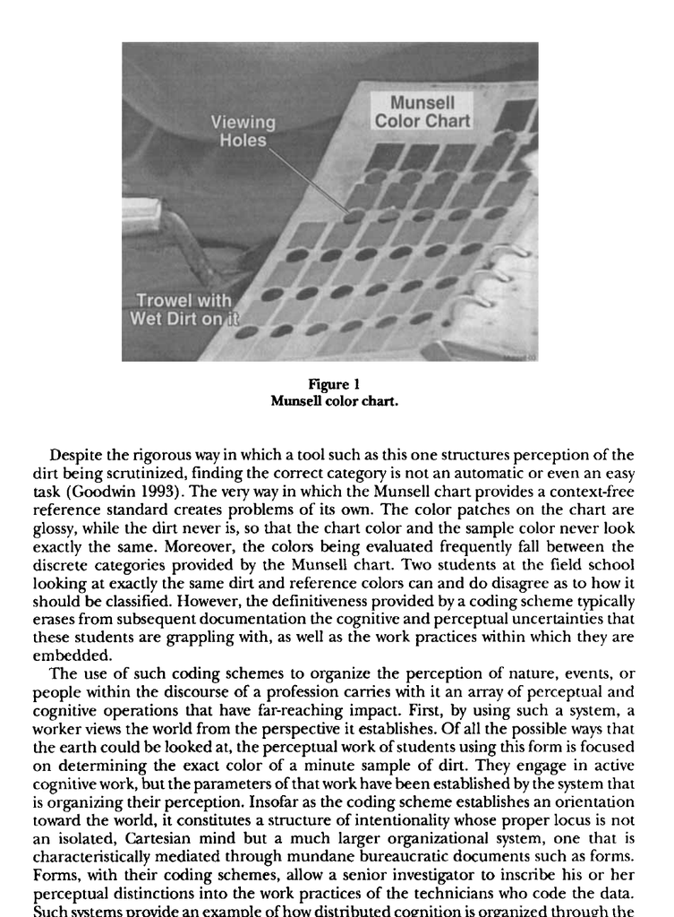

The Munsell chart provides a shared set of categories for describing soil colour.

It does not merely store a perception. It helps archaeologists produce a comparable observation.

Goodwin (1994), pp. 608–610. Screenshot from the published article.

## In the Rodney King trial, the same movement was coded in opposing ways

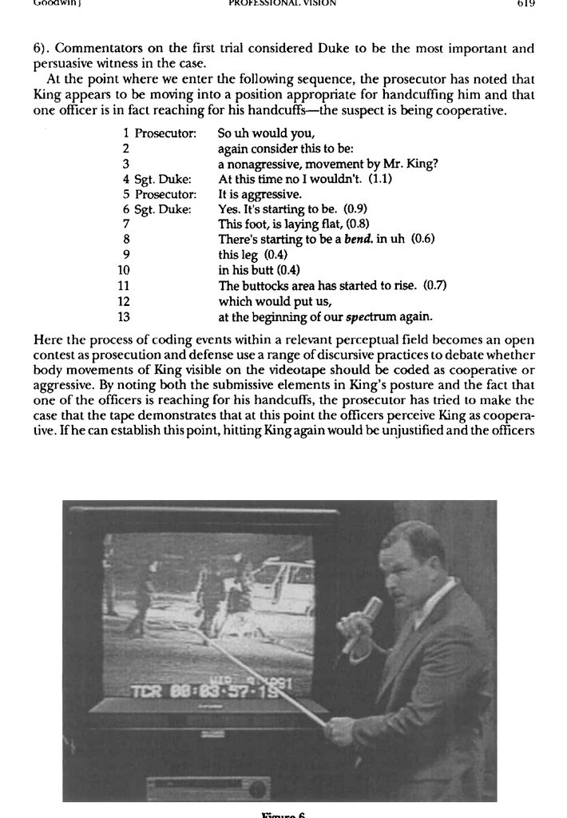

The prosecution and defence organized attention to different parts of the video.

Terms such as **aggressive** and **nonaggressive** made the movement legible within competing accounts.

Goodwin (1994), pp. 619–621. Screenshot from the published article.

## Highlighting can make one feature appear decisive

[figure not shown]

Cropping and highlighting altered the figure–ground relation: one movement became central while surrounding action receded.

Goodwin (1994), pp. 623–625. Screenshot from the published article.

## Heinlein follows professional vision into AI-assisted colonoscopy

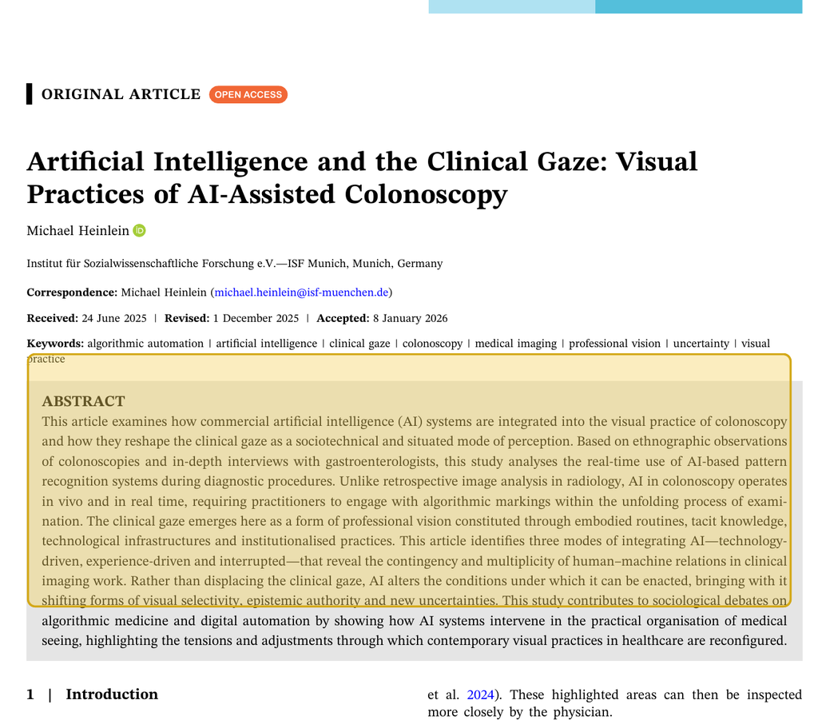

Heinlein observed colonoscopies and interviewed gastroenterologists using commercial AI systems.

The software marks possible polyps on screen in real time. Clinicians may follow, override or be interrupted by those markings.

**The sociological question is how an algorithm changes what becomes noticeable and authoritative during the procedure.**

Heinlein, Michael. 2026. “Artificial Intelligence and the Clinical Gaze: Visual Practices of AI-Assisted Colonoscopy.” *Sociology of Health & Illness* 48:e70144. https://doi.org/10.1111/1467-9566.70144.

## These traditions give us three questions for any recorded scene

**1. Access**What could this observer or device perceive? *(Simmel)*

**2. Sequence**What action preceded the response? *(Mead; sequence analysis)*

**3. Representation**How were features selected, coded and highlighted? *(Goodwin)*

Goffman adds a fourth reminder: the people, rules and audiences around the action are part of the situation.

## Video sequence analysis begins with the quality of the record

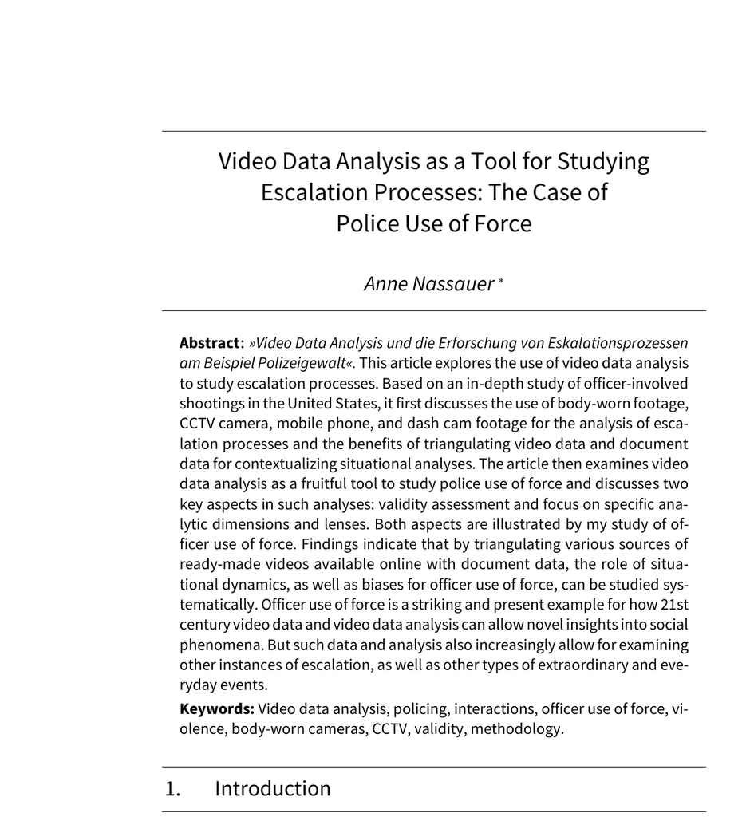

Nassauer studies escalation by reconstructing interactions moment by moment.

The method depends on whether video adequately captures the relevant duration, camera angle, resolution and sound.

Nassauer, Anne. 2022. “Video Data Analysis as a Tool for Studying Escalation Processes: The Case of Police Use of Force.” *Historical Social Research* 47(1):36–57. https://doi.org/10.12759/hsr.47.2022.02.

## Different cameras answer different questions

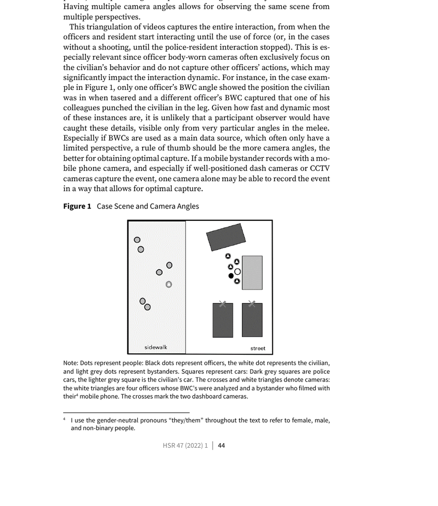

**Wide view:** spatial organization and surrounding actors.

**Close view:** gesture, posture and contact.

**Multiple angles:** checking whether an apparent action is an artefact of position.

Nassauer (2022), Figure 1. Screenshot from the published article.

## The analytic object is an ordered interaction

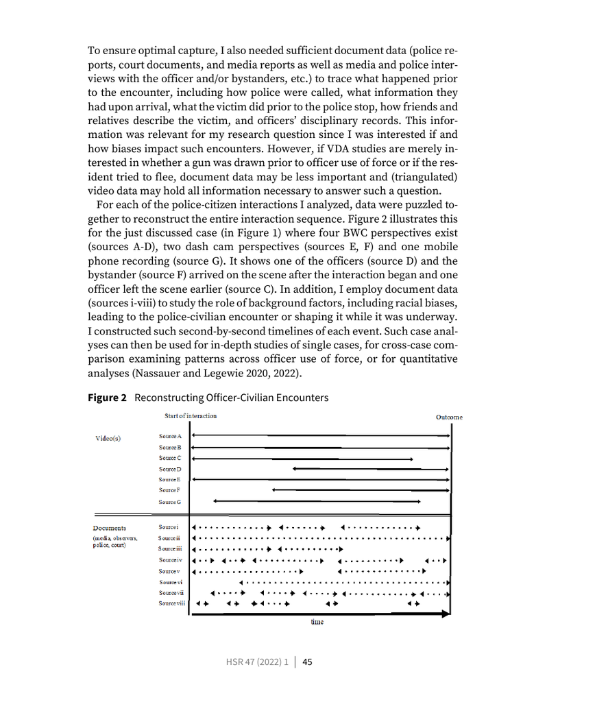

Nassauer codes when actions occur and reconstructs their order.

This permits comparison of timing, turn-taking, escalation and de-escalation across cases.

Nassauer (2022), Figure 2. Screenshot from the published article.

## For our case, the source record should come before interpretation

**Source**Official FIFA broadcast and tactical-camera clips

**Event**France v. Italy, World Cup final, 9 July 2006

**Segment**Exchange preceding the head-butt and immediate aftermath

**Available**moving image, camera-selected sound, timestamps

**Missing**clear recording of the players’ words; bodily experience

## A public clip is not a neutral sample of social life

all interactions in the match

actions captured by a camera

moments selected for broadcast

clips edited and uploaded

frames given to a model

At every step, some material becomes easier to study and other material disappears.

Nassauer, Anne, and Nicolas M. Legewie. 2021 [online first 2018]. “Video Data Analysis: A Methodological Frame for a Novel Research Trend.” *Sociological Methods & Research* 50(1):135–174; Nassauer (2022), *Historical Social Research* 47(1):36–57.

## Collins asks why confrontations so often fail to become violence

Why does most face-to-face confrontation**not become effective violence?**

Collins shifts attention away from a violent type of person and towards the interaction itself.

Confrontation usually produces tension and fear. The question is how particular situations get around that barrier.

Collins, Randall. 2008. *Violence: A Micro-sociological Theory*. Princeton University Press.

## His comparison starts with situations, not types of people

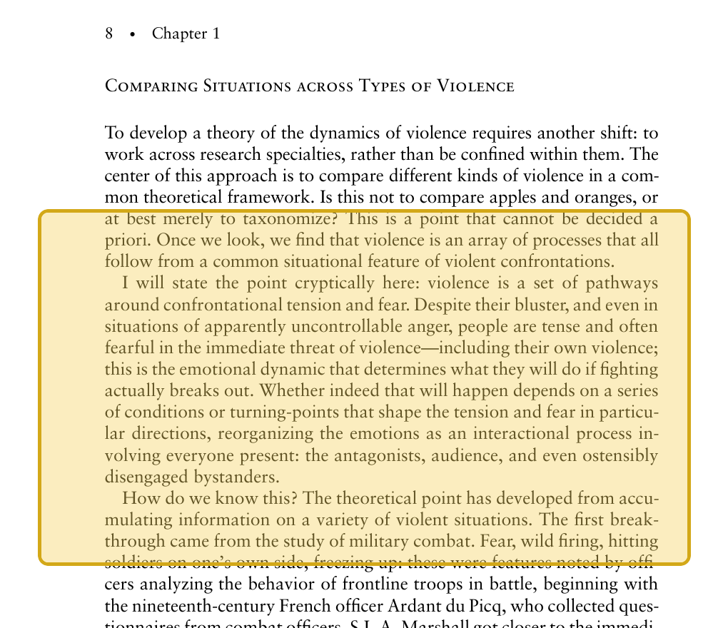

Collins compares violent and nonviolent encounters to identify emotional dynamics and turning points.

The “barrier” of confrontational tension and fear is an empirical problem to explain.

Collins (2008), Chapter 1, pp. 8–10. Screenshot from the published book chapter.

## Collins identifies several routes around that barrier

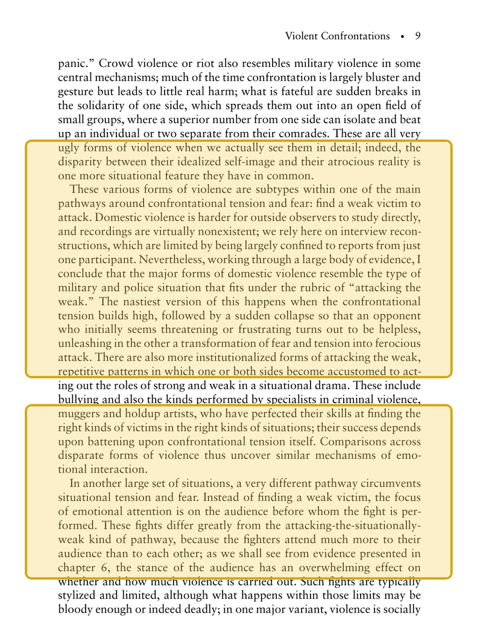

Examples include attacking a weak victim, staged fights oriented to an audience, and a sudden shift that gives one side emotional dominance.

These are comparative propositions—not labels that can be read automatically from a frame.

Collins (2008), Chapter 1, pp. 9–11. Screenshot from the published book chapter.

## “Tunnel of violence” refers to a more extended altered state

### Collins’s claim

In some violent episodes, participants describe altered time, narrowed vision, changed sound and a diminished sense of self.

### What our clip establishes

A brief sequence of movement and contact. The footage alone does not establish that Zidane entered such a state.

Collins, Randall. 2013. “Entering and Leaving the Tunnel of Violence.” *Current Sociology* 61(2):132–151.

## The theoretical question is narrower than “why did he do it?”

What changed in the interaction immediately before physical contact?

We can inspect timing, distance, orientation, gesture and response. Claims about insult, intention, masculinity or emotion require additional evidence.

## We can now inspect the sequence without naming motives

[figure not shown]

players close together

movement downfield

Zidane turns

[figure not shown]

camera follows the action

Frames from official FIFA broadcast footage. Descriptions state only what is visible in each selected frame.

## A frame-by-frame record still needs continuous video

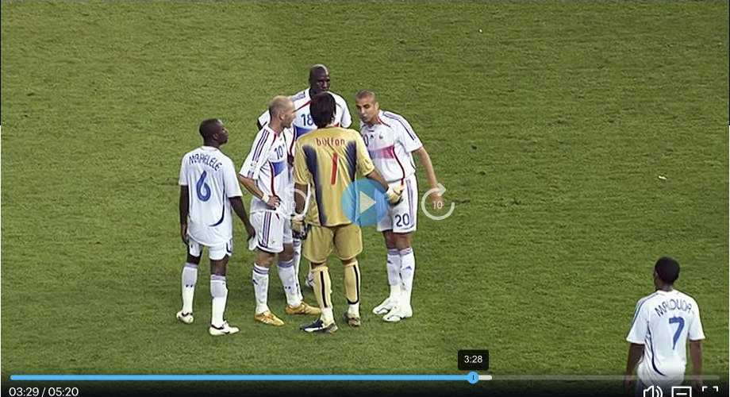

**A still can show:** position, posture, visible contact and who is in frame.

**It cannot show by itself:** duration, speed, trajectory or the order between adjacent movements.

**Method:** inspect the clip, then use frames to document particular moments.

## Observation and interpretation should be recorded separately

| Statement | Status | What would support it? |
| --- | --- | --- |
| Zidane turns and moves toward Materazzi. | Observed | Ordered video frames |
| Materazzi says something during the exchange. | Partly observed | Visible speech; words unavailable |
| The insult caused the head-butt. | Causal interpretation | Participant accounts plus sequence |
| The exchange crossed Collins’s barrier of confrontational tension and fear. | Collins-style interpretation | Sequence evidence plus comparison with confrontations that do not become violent |

## Published accounts make different claims from different evidence

**Interactional situation**

Collins asks how confrontational dynamics make violence possible or inhibit it.

Collins 2008

**Masculinity and habitus**

Morrissey reads the incident through Elias and Bourdieu, using Zidane’s biography and public meaning.

Morrissey 2009

**Strategic anger**

Experimental work asks whether anger after provocation can affect subsequent performance.

Furley et al. 2014

These explanations are not interchangeable. Each requires evidence beyond a single image.

## A deliberately strong interpretation for us to discuss

“draws on the work of Norbert Elias and Pierre Bourdieu and argues that Materazzi’s insults acted as a catalyst, causing divergent aspects of Zidane’s fractured habitus to clash, and the dispositions of the Franco-Kabyle habitus to override the ‘civilized’ habitus demanded by the illusion generated by the professional football field”

What evidence would we need before accepting this explanation?

Morrissey, Sean. 2009. “‘Un homme avant tout’: Zinedine Zidane and the Sociology of a Head-butt.” *Soccer & Society* 10(2):210–225. Abstract.

## Even the official thumbnail tells viewers how to see the act

[figure not shown]

The phrase **“moments of madness”** supplies an interpretation before the video starts.

Goodwin’s point is useful here: text, cropping and repetition organize attention.

## We will use an LLM as another observer of the record

1

**Give the model one frame**Ask only for visible actions and explicit uncertainty.

2

**Add an adjacent frame**See which claims change when sequence is available.

3

**Check the response**Compare each claim with the frame and source record.

## First input: one image and a deliberately narrow instruction

**Prompt**

Describe only visible positions and actions. Do not infer speech, intention or emotion. For anything uncertain, write `uncertain`. Return JSON with the keys `visible_actions` and `limits`.

## Example output: useful, but still open to checking

**`visible_actions`**

- Two players are moving in the same direction.
- The player in white turns his upper body toward the player in blue.

**`limits`**

- The image does not show what either player said.
- Intention and emotion cannot be determined from this frame.

**Three checks:** Does every action appear in the frame? · Has the model added a motive? · What does one still fail to show?

## More context helps—but it can also invite outside knowledge

**New prompt**

Compare these frames in order. Describe only a change that is visible across them. Do not infer why it occurred.

**Unconstrained response**

“Zidane turns back toward Materazzi.”

The identification may be correct, but it comes from the model’s prior knowledge rather than these pixels alone.

**Constrained response**

“The player in white changes from moving downfield to turning his body toward the player in blue.”

## The researcher records corrections next to the model response

**Model description**

“The player in white turns toward the player in blue.”

**Researcher check**

Supported across frames 2–3. Direction of gaze is unclear at this resolution.

**Source detail**

FIFA broadcast clip; selected adjacent frames; speech unavailable.

Keeping all three entries lets another reader see the source, the model’s proposal and the human revision.